# Democracy & Gender in Leadership

Visualizations

**Women in Parliament by Democratic Status**

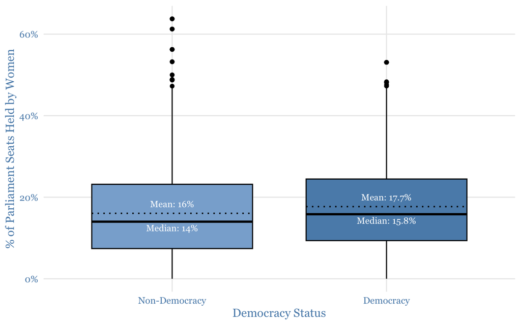

**Average Accession Ages**

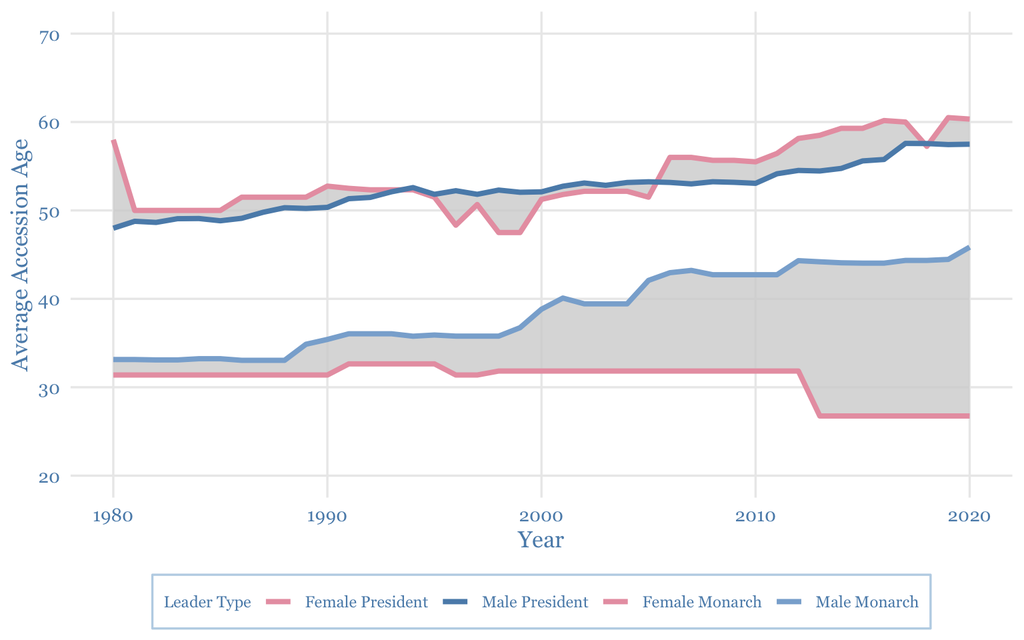

Tables

**Women in Parliament**

**Table 1: Welch Two-Sample t-Test**

Proportion of Parliament Seats Held by Women

| Mean (Non-Dem.) | Mean (Dem.) | *t* | *p*-value<sup>1</sup> | CI Low | CI High | *df* |
| --- | --- | --- | --- | --- | --- | --- |
| 16.047 | 17.701 | −4.591 | 4.563 × 10<sup>−6</sup> | −2.359 | −0.947 | 3,382.5 |

<sup>1</sup> Highlighted p-value is statistically significant (p < 0.05).

The t-test (t = -4.591, p < 0.001) confirms a statistically significant difference in women’s parliamentary representation between democratic and non-democratic countries. Democratic countries average **17.7%** versus **16.0%** for non-democracies, with a confidence interval that excludes zero.

**Accession Ages Over Time**

**Table 2: Gender Gaps in Accession Age**

Average Age When Leaders First Take Office

| Status | N | Presidents Female | Presidents Male | Presidents Gap (M-F)<sup>1</sup> | Monarchs Female | Monarchs Male | Monarchs Gap (M-F)<sup>1</sup> |
| --- | --- | --- | --- | --- | --- | --- | --- |
| Non-Democracy | 8,000 | 62.4 | 48.6 | −13.7 | 27.6 | 34.7 | 7.1 |
| Democracy | 6,706 | 54.2 | 57.0 | 2.8 | 31.0 | 38.7 | 7.7 |

<sup>1</sup> Blue = males higher; pink = females higher.

In non-democratic countries, female presidents take office nearly **14 years older** than male presidents on average. In democracies, that gap shrinks to under 3 years. For monarchs, the pattern reverses — female monarchs tend to ascend younger, and the gap has been growing since 2000.

**Gender Gaps by Decade**

**Table 3: Gender Gaps by Decade**

| Decade | Sample Size | Prop. Female President | Prop. Male President | Gap (M - F)<sup>1</sup> |
| --- | --- | --- | --- | --- |
| 1950s | 2,080 | 0.0% | 100.0% | 100.0% |
| 1960s | 2,080 | 0.0% | 100.0% | 100.0% |
| 1970s | 2,080 | 0.1% | 99.9% | 99.8% |
| 1980s | 2,080 | 1.7% | 98.3% | 96.6% |
| 1990s | 2,080 | 2.2% | 97.8% | 95.5% |
| 2000s | 2,080 | 4.4% | 95.6% | 91.2% |
| 2010s | 2,288 | 7.0% | 93.0% | 86.1% |

<sup>1</sup> Positive gap means more male than female presidents. Gap narrows across decades.

Women in Parliament vs. Female Population

[interactive chart not shown]

Global Distribution of Female Leadership and Representation From 1950-2020

Honduras Trends

**Honduras as a Representative Case**

Honduras had 6 transitions in and out of democracy. The difference from the average proportion of women in parliament from before 2005 and after 2020 was 0.5212923, which is pretty close to the average as well. So, it both represents the global trend for women in parliament pretty well, but acts as an outlier for the number of transitions in and out of democracy.

We found data about Honduras through the World Bank database, which includes data about over 1,300 categories about Honduras, including information about population breakdowns, social issues, climate change, and economic-related things. The data was collected from 1960–2025, and we cleaned it to have each row represent one year.

**Women in Parliament Trends**

The female population in Honduras remains relatively constant over time. However, the percentage of women in parliament fluctuates throughout the years. In 1997, only about 9% of seats in parliament were occupied by women, and in 2002, this percentage dropped to around 5.5%. 2005 saw a significant increase of 23% in the percentage of women in parliament. This percentage has varied since then, however the percentage of women in parliament seems to be on the rise, with almost 30% of seats being held by women in 2025.

**Global Trends**

South America has a large concentration of female leaders. There are also a few European, African, and Asian countries with either female monarchs or presidents. Generally, it seems that smaller territories and countries, such as the Cayman Islands and Nepal, have female leaders more than larger countries. The map also reveals that countries with female leaders don’t necessarily have a large proportion of women in parliament. For example, Liberia, South Korea, and Greece are some countries who once had female leaders, but have low proportions of women in parliament.

Taken together, these findings show that becoming a democratic country can be associated with greater gender representation and broader political change, but maintaining democratic rule and achieving gender equality remain ongoing challenges. Democracy may create more opportunities for representation, but the persistence of gender gaps and repeated regime transitions show that political progress is not automatic or permanent.